Required Packages and settings:

```r
library(tidyverse)
library(data.table)
```

```r
library(ggplot2)
library(dplyr)
library(xtable)
```

Reading in Data, I’ll assume that you have set your Working Directory, and the file downloaded accordingly off the web.

```r
StormData <- read.csv("Data/repdata_data_StormData.csv.bz2"
                      , header = TRUE
                      , sep = ",")
```

What it do?

```r
summary(StormData)
```

```
##     STATE__       BGN_DATE           BGN_TIME          TIME_ZONE
##  Min.   : 1.0   Length:902297      Length:902297      Length:902297
##  1st Qu.:19.0   Class :character   Class :character   Class :character
##  Median :30.0   Mode  :character   Mode  :character   Mode  :character
##  Mean   :31.2
##  3rd Qu.:45.0
##  Max.   :95.0
##
##      COUNTY       COUNTYNAME           STATE              EVTYPE
##  Min.   :  0.0   Length:902297      Length:902297      Length:902297
##  1st Qu.: 31.0   Class :character   Class :character   Class :character
##  Median : 75.0   Mode  :character   Mode  :character   Mode  :character
##  Mean   :100.6
##  3rd Qu.:131.0
##  Max.   :873.0
##
##    BGN_RANGE          BGN_AZI           BGN_LOCATI          END_DATE
##  Min.   :   0.000   Length:902297      Length:902297      Length:902297
##  1st Qu.:   0.000   Class :character   Class :character   Class :character
##  Median :   0.000   Mode  :character   Mode  :character   Mode  :character
##  Mean   :   1.484
##  3rd Qu.:   1.000
##  Max.   :3749.000
##
##    END_TIME           COUNTY_END COUNTYENDN       END_RANGE
##  Length:902297      Min.   :0    Mode:logical   Min.   :  0.0000
##  Class :character   1st Qu.:0    NA's:902297    1st Qu.:  0.0000
##  Mode  :character   Median :0                   Median :  0.0000
##                     Mean   :0                   Mean   :  0.9862
##                     3rd Qu.:0                   3rd Qu.:  0.0000
##                     Max.   :0                   Max.   :925.0000
##
##    END_AZI           END_LOCATI            LENGTH              WIDTH
##  Length:902297      Length:902297      Min.   :   0.0000   Min.   :   0.000
##  Class :character   Class :character   1st Qu.:   0.0000   1st Qu.:   0.000
##  Mode  :character   Mode  :character   Median :   0.0000   Median :   0.000
##                                        Mean   :   0.2301   Mean   :   7.503
##                                        3rd Qu.:   0.0000   3rd Qu.:   0.000
##                                        Max.   :2315.0000   Max.   :4400.000
##
```

[output cut: 25 more lines]

```
##  Min.   :-14451   Min.   :   0   Min.   :-14455   Length:902297
##  1st Qu.:  7247   1st Qu.:   0   1st Qu.:     0   Class :character
##  Median :  8707   Median :   0   Median :     0   Mode  :character
##  Mean   :  6940   Mean   :1452   Mean   :  3509
##  3rd Qu.:  9605   3rd Qu.:3549   3rd Qu.:  8735
##  Max.   : 17124   Max.   :9706   Max.   :106220
##                   NA's   :40
##      REFNUM
##  Min.   :     1
##  1st Qu.:225575
##  Median :451149
##  Mean   :451149
##  3rd Qu.:676723
##  Max.   :902297
##
```

```r
str(StormData)
```

```
## 'data.frame':    902297 obs. of  37 variables:
##  $ STATE__   : num  1 1 1 1 1 1 1 1 1 1 ...
##  $ BGN_DATE  : chr  "4/18/1950 0:00:00" "4/18/1950 0:00:00" "2/20/1951 0:00:00" "6/8/1951 0:00:00" ...
##  $ BGN_TIME  : chr  "0130" "0145" "1600" "0900" ...
##  $ TIME_ZONE : chr  "CST" "CST" "CST" "CST" ...
##  $ COUNTY    : num  97 3 57 89 43 77 9 123 125 57 ...
##  $ COUNTYNAME: chr  "MOBILE" "BALDWIN" "FAYETTE" "MADISON" ...
##  $ STATE     : chr  "AL" "AL" "AL" "AL" ...
##  $ EVTYPE    : chr  "TORNADO" "TORNADO" "TORNADO" "TORNADO" ...
##  $ BGN_RANGE : num  0 0 0 0 0 0 0 0 0 0 ...
##  $ BGN_AZI   : chr  "" "" "" "" ...
##  $ BGN_LOCATI: chr  "" "" "" "" ...
##  $ END_DATE  : chr  "" "" "" "" ...
##  $ END_TIME  : chr  "" "" "" "" ...
##  $ COUNTY_END: num  0 0 0 0 0 0 0 0 0 0 ...
```

[output cut: 23 more lines]

```r
head(StormData)
```

```
##   STATE__           BGN_DATE BGN_TIME TIME_ZONE COUNTY COUNTYNAME STATE  EVTYPE
## 1       1  4/18/1950 0:00:00     0130       CST     97     MOBILE    AL TORNADO
## 2       1  4/18/1950 0:00:00     0145       CST      3    BALDWIN    AL TORNADO
## 3       1  2/20/1951 0:00:00     1600       CST     57    FAYETTE    AL TORNADO
## 4       1   6/8/1951 0:00:00     0900       CST     89    MADISON    AL TORNADO
## 5       1 11/15/1951 0:00:00     1500       CST     43    CULLMAN    AL TORNADO
## 6       1 11/15/1951 0:00:00     2000       CST     77 LAUDERDALE    AL TORNADO
##   BGN_RANGE BGN_AZI BGN_LOCATI END_DATE END_TIME COUNTY_END COUNTYENDN
## 1         0                                               0         NA
## 2         0                                               0         NA
## 3         0                                               0         NA
## 4         0                                               0         NA
## 5         0                                               0         NA
## 6         0                                               0         NA
##   END_RANGE END_AZI END_LOCATI LENGTH WIDTH F MAG FATALITIES INJURIES PROPDMG
```

[output cut: 20 more lines]

First we are ensuring that we are getting a non-zero number in atleast one of the “fatalities, injuries, property damage, and crop damage” categories. After all, if they are not causing measurable damage they should not show up in our findings.

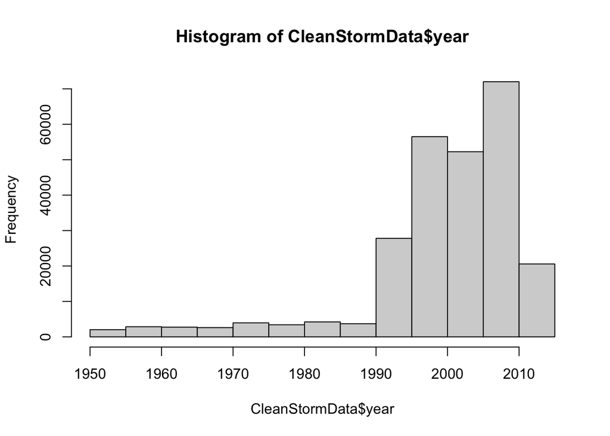

```r
CleanStormData <- subset(StormData, (FATALITIES > 0 | INJURIES > 0 |
                                    PROPDMG > 0 | CROPDMG > 0)
                                  , select =c("BGN_DATE"
                                             ,"STATE"
                                             ,"EVTYPE"
                                             ,"FATALITIES"
                                             ,"INJURIES"
                                             ,"PROPDMG"
                                             ,"PROPDMGEXP"
                                             ,"CROPDMG"
                                             ,"CROPDMGEXP"))

CleanStormData$year <- as.numeric(format(
                                  as.Date(CleanStormData$BGN_DATE
                                        , format = "%m/%d/%Y %H:%M:%S"),"%Y"))

hist(CleanStormData$year, breaks = 10)
```

```r
CleanStormData$EVTYPE <- toupper(CleanStormData$EVTYPE)
```

Now, we’re running into our second problem, the Property Damage and Crop Damage columns. These documentation suggests that we get the following:

Symbol Magnitude “B” Billion “M” Million “K” Thousand

Simple enough. Lets see what we get.

```r
table(CleanStormData$PROPDMGEXP)
```

```
##
##             -      +      0      2      3      4      5      6      7      B
##  11585      1      5    210      1      1      4     18      3      3     40
##      h      H      K      m      M
##      1      6 231428      7  11320
```

```r
table(CleanStormData$CROPDMGEXP)
```

```
##
##             ?      0      B      k      K      m      M
## 152664      6     17      7     21  99932      1   1985
```

Alright, so there are a few other characters listed, including blanks

I’m making a few assumptions here:

```
1.) The capitalization is user generated and has no "real" difference. A "M"
    will be treated the same as "m"

2.) The "H"/"h" character symbolizes a magnification of 100

3.) The "-", "+", "0" "?" characters are missing value characters and will
    have magnification of 1 (identity property)

4.) The numeric "2", "3", etc. yield the appropriate 10^X magnification,
    where X = "2", X = "3" respectively.
```

With those assumptions in mind, here is the cleaning for the Economic devastation

```r
head(toupper(CleanStormData$PROPDMGEXP),3)
```

```
## [1] "K" "K" "K"
```

```r
head(toupper(CleanStormData$CROPDMGEXP),3)
```

```
## [1] "" "" ""
```

```r
Magnification <- function(exp) {
    exp <- toupper(exp);
    if (exp == "")  return (10^0);
    if (exp == "-") return (10^0);
    if (exp == "?") return (10^0);
    if (exp == "+") return (10^0);
    if (exp == "0") return (10^0);
    if (exp == "1") return (10^1);
    if (exp == "2") return (10^2);
    if (exp == "3") return (10^3);
    if (exp == "4") return (10^4);
    if (exp == "5") return (10^5);
    if (exp == "6") return (10^6);
    if (exp == "7") return (10^7);
    if (exp == "8") return (10^8);
    if (exp == "9") return (10^9);
    if (exp == "H") return (10^2);
    if (exp == "K") return (10^3);
    if (exp == "M") return (10^6);
    if (exp == "B") return (10^9);
    return (NA);
}

CleanStormData$TotalPropCost <- with(CleanStormData, as.numeric(PROPDMG)
                               * sapply(PROPDMGEXP, Magnification))/10^9

CleanStormData$TotalCropCost <- with(CleanStormData, as.numeric(CROPDMG)
                              * sapply(CROPDMGEXP, Magnification))/10^9
```

Our final step before actually plotting and visualizing our results is making sure that our data is properly aggregated (by sum) and ordered.

```r
#Impact on Public Health
Fatalities <- aggregate(x = list(Impact = CleanStormData$FATALITIES)
                               , by = list(EVENT_TYPE = CleanStormData$EVTYPE)
                               , FUN = sum)

Fatalities <- Fatalities[order(Fatalities$Impact,
                               decreasing = TRUE),]

# Impact on the Economy
PropertyCost <- aggregate(x = list(Impact = CleanStormData$TotalPropCost)
                                 , by = list(EVENT_TYPE= CleanStormData$EVTYPE)
                                 , FUN = sum)

PropertyCost <- PropertyCost[order(PropertyCost$Impact,
                                   decreasing = TRUE),]

CropCost <- aggregate(x = list(Impact = CleanStormData$TotalCropCost)
                              , by = list(EVENT_TYPE = CleanStormData$EVTYPE)
                              , FUN = sum)

CropCost <- CropCost[order(CropCost$Impact,
                           decreasing = TRUE),]
```

At this point, we are finally ready to visualize our results!

```r
print(xtable(head(PropertyCost, 10),
             caption = "Top 10 Weather Events Most Harmful to Property"),
             caption.placement = 'top',
             type = "html",
             include.rownames = FALSE,
             html.table.attributes='class="table-bordered", width="100%"')
```

```
## <!-- html table generated in R 4.0.3 by xtable 1.8-4 package -->
## <!-- Tue Feb  2 14:13:06 2021 -->
## <table class="table-bordered", width="100%">
## <caption align="top"> Top 10 Weather Events Most Harmful to Property </caption>
## <tr> <th> EVENT_TYPE </th> <th> Impact </th>  </tr>
##   <tr> <td> FLOOD </td> <td align="right"> 144.66 </td> </tr>
##   <tr> <td> HURRICANE/TYPHOON </td> <td align="right"> 69.31 </td> </tr>
##   <tr> <td> TORNADO </td> <td align="right"> 56.95 </td> </tr>
##   <tr> <td> STORM SURGE </td> <td align="right"> 43.32 </td> </tr>
##   <tr> <td> FLASH FLOOD </td> <td align="right"> 16.82 </td> </tr>
##   <tr> <td> HAIL </td> <td align="right"> 15.74 </td> </tr>
##   <tr> <td> HURRICANE </td> <td align="right"> 11.87 </td> </tr>
##   <tr> <td> TROPICAL STORM </td> <td align="right"> 7.70 </td> </tr>
##   <tr> <td> WINTER STORM </td> <td align="right"> 6.69 </td> </tr>
##   <tr> <td> HIGH WIND </td> <td align="right"> 5.27 </td> </tr>
##    </table>
```

```r
print(xtable(head(CropCost, 10),
             caption = "Top 10 Weather Events Most Harmful to Crops"),
             caption.placement = 'top',
             type = "html",
             include.rownames = FALSE,
             html.table.attributes='class="table-bordered", width="100%"')
```

```
## <!-- html table generated in R 4.0.3 by xtable 1.8-4 package -->
## <!-- Tue Feb  2 14:13:06 2021 -->
## <table class="table-bordered", width="100%">
## <caption align="top"> Top 10 Weather Events Most Harmful to Crops </caption>
## <tr> <th> EVENT_TYPE </th> <th> Impact </th>  </tr>
##   <tr> <td> DROUGHT </td> <td align="right"> 13.97 </td> </tr>
##   <tr> <td> FLOOD </td> <td align="right"> 5.66 </td> </tr>
##   <tr> <td> RIVER FLOOD </td> <td align="right"> 5.03 </td> </tr>
##   <tr> <td> ICE STORM </td> <td align="right"> 5.02 </td> </tr>
##   <tr> <td> HAIL </td> <td align="right"> 3.03 </td> </tr>
##   <tr> <td> HURRICANE </td> <td align="right"> 2.74 </td> </tr>
##   <tr> <td> HURRICANE/TYPHOON </td> <td align="right"> 2.61 </td> </tr>
##   <tr> <td> FLASH FLOOD </td> <td align="right"> 1.42 </td> </tr>
##   <tr> <td> EXTREME COLD </td> <td align="right"> 1.31 </td> </tr>
##   <tr> <td> FROST/FREEZE </td> <td align="right"> 1.09 </td> </tr>
##    </table>
```

```r
print(xtable(head(Fatalities, 10),
             caption = "Top 10 Deadliest Weather Events"),
             caption.placement = 'top',
             type = "html",
             include.rownames = FALSE,
             html.table.attributes='class="table-bordered", width="100%"')
```

```
## <!-- html table generated in R 4.0.3 by xtable 1.8-4 package -->
## <!-- Tue Feb  2 14:13:06 2021 -->
## <table class="table-bordered", width="100%">
## <caption align="top"> Top 10 Deadliest Weather Events </caption>
## <tr> <th> EVENT_TYPE </th> <th> Impact </th>  </tr>
##   <tr> <td> TORNADO </td> <td align="right"> 5633.00 </td> </tr>
##   <tr> <td> EXCESSIVE HEAT </td> <td align="right"> 1903.00 </td> </tr>
##   <tr> <td> FLASH FLOOD </td> <td align="right"> 978.00 </td> </tr>
##   <tr> <td> HEAT </td> <td align="right"> 937.00 </td> </tr>
##   <tr> <td> LIGHTNING </td> <td align="right"> 816.00 </td> </tr>
##   <tr> <td> TSTM WIND </td> <td align="right"> 504.00 </td> </tr>
##   <tr> <td> FLOOD </td> <td align="right"> 470.00 </td> </tr>
##   <tr> <td> RIP CURRENT </td> <td align="right"> 368.00 </td> </tr>
##   <tr> <td> HIGH WIND </td> <td align="right"> 248.00 </td> </tr>
##   <tr> <td> AVALANCHE </td> <td align="right"> 224.00 </td> </tr>
##    </table>
```

First we are going to visualize the most damaging events to the US economy, the property and weather related costs. After picking the “top 10” most dangerous events in each category. Floods and droughts are bad.

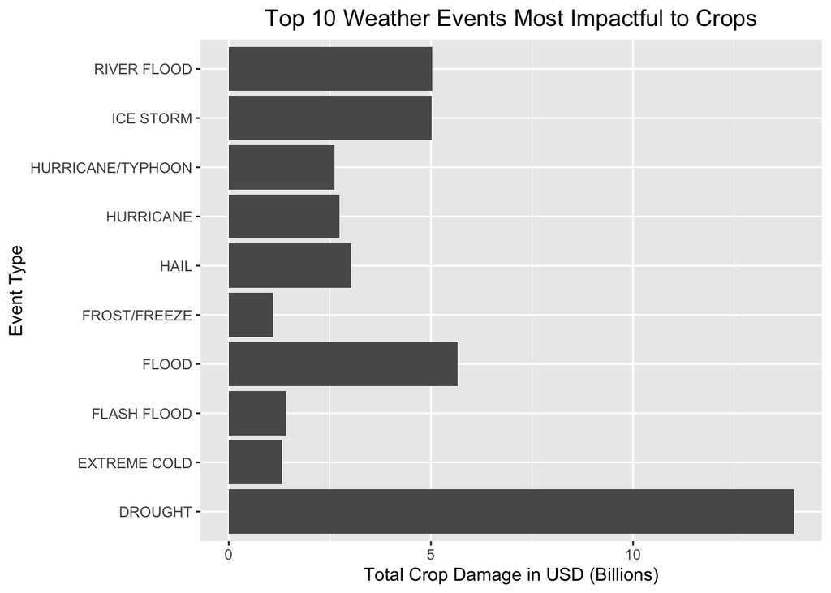

```r
CropCostPlot <- ggplot(head(CropCost,10)
                      , aes(x = EVENT_TYPE
                          , y = Impact)) +
                geom_bar(stat = "Identity") +
                coord_flip() +
                xlab("Event Type") +
                ylab("Total Crop Damage in USD (Billions)") +
                theme(plot.title = element_text(size = 14
                                                , hjust = 0.5)) +
                ggtitle("Top 10 Weather Events Most Impactful to Crops")

PropertyCostPlot <- ggplot(head(PropertyCost,10)
                      , aes(x = EVENT_TYPE
                          , y = Impact)) +
                geom_bar(stat = "Identity") +
                coord_flip() +
                xlab("Event Type") +
                ylab("Total Crop Damage in USD (Billions)") +
                theme(plot.title = element_text(size = 14
                                                , hjust = 0.5)) +
                ggtitle("Top 10 Weather Events Most Impactful to Property")

print(CropCostPlot)
```

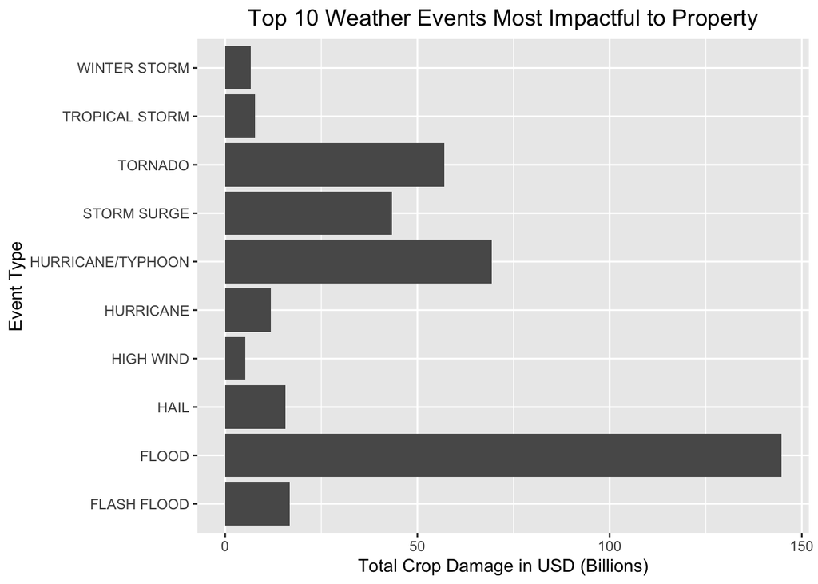

```r
print(PropertyCostPlot)
```

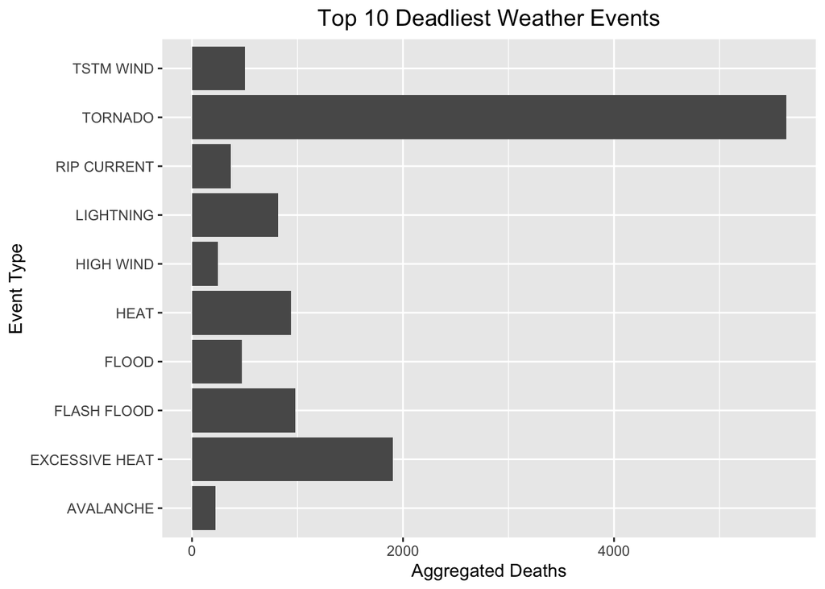

```r
FatalitiesPlot <- ggplot(head(Fatalities,10)
                      , aes(x = EVENT_TYPE
                          , y = Impact)) +
                geom_bar(stat = "Identity") +
                coord_flip() +
                xlab("Event Type") +
                ylab("Aggregated Deaths") +
                theme(plot.title = element_text(size = 14
                                                , hjust = 0.5)) +
                ggtitle("Top 10 Deadliest Weather Events")


print(FatalitiesPlot)
```

Who Knew? Tornadoes = Bad